# Reproducible Research: Peer Assessment 1

## Introduction:

This project demonstrates how to write a report in a sigle R markdown document through answering the questions of assignments. Data and questions can be downloaded from the [“Reproducible Research” course webpage](https://www.coursera.org/course/repdata). Data is collecting from a personal activity monitoring device at 5-minute intervals through out the day and consists of two months of data collected during the months of October and November, 2012.

To make a start on the assignment, Rstudio is implemented.

#### Prepare the R environment

Setting the global option to show the code with echo = TRUE and makes each time of running in html faster when setting cache equals TRUE.

```r
library(knitr)
opts_chunk$set(echo = TRUE,results = "hold", cache = TRUE)
```

Loading the data from the “activity.csv” file

```r
activity <- read.csv("activity.csv", colClasses = c("numeric", "Date", "numeric"))
```

To understand the data briefly, the following codes are used:

```r
head(activity)
```

```
##   steps       date interval
## 1    NA 2012-10-01        0
## 2    NA 2012-10-01        5
## 3    NA 2012-10-01       10
## 4    NA 2012-10-01       15
## 5    NA 2012-10-01       20
## 6    NA 2012-10-01       25
```

```r
names(activity)
```

```
## [1] "steps"    "date"     "interval"
```

```r
str(activity)
```

```
## 'data.frame':    17568 obs. of  3 variables:
##  $ steps   : num  NA NA NA NA NA NA NA NA NA NA ...
##  $ date    : Date, format: "2012-10-01" "2012-10-01" ...
##  $ interval: num  0 5 10 15 20 25 30 35 40 45 ...
```

```r
summary(activity)
```

```
##      steps             date               interval
##  Min.   :  0.00   Min.   :2012-10-01   Min.   :   0.0
##  1st Qu.:  0.00   1st Qu.:2012-10-16   1st Qu.: 588.8
##  Median :  0.00   Median :2012-10-31   Median :1177.5
##  Mean   : 37.38   Mean   :2012-10-31   Mean   :1177.5
##  3rd Qu.: 12.00   3rd Qu.:2012-11-15   3rd Qu.:1766.2
##  Max.   :806.00   Max.   :2012-11-30   Max.   :2355.0
##  NA's   :2304
```

#### What is mean total number of steps taken per day?

To calculate the total number of steps taken per day, the aggregate function is called and NA is also removed from the data.

```r
Total_Steps <- aggregate(steps ~ date, data = activity, sum, na.rm = TRUE)
```

The following is the last 6 numbers tail of the total steps taken per day:

```r
Total_StepsTail <- tail(Total_Steps)
Total_StepsTail$steps
```

```
## [1] 14478 11834 11162 13646 10183  7047
```

To show histogram of total numbers of steps taken per day:

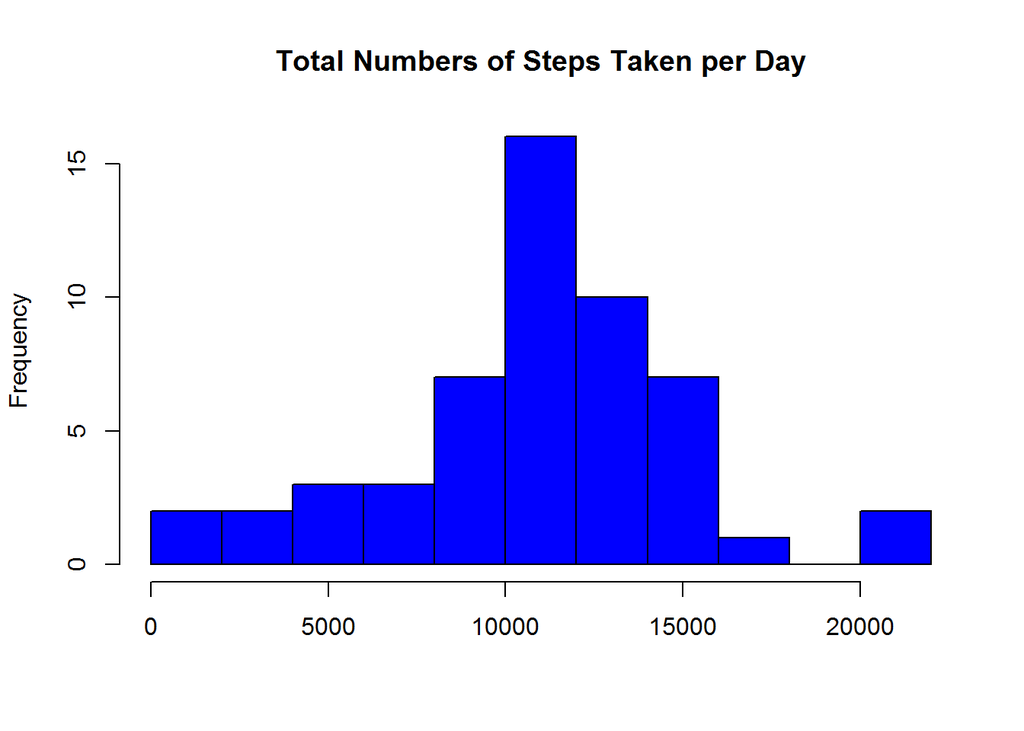

```r
hist(Total_Steps$steps, xlab = " ", main = "Total Numbers of Steps Taken per Day", col= "blue",breaks = 10)
```

To calculate its mean and median:

```r
itsMean <- mean(Total_Steps$steps)
itsMean
```

```
## [1] 10766.19
```

```r
itsMedian <- median(Total_Steps$steps)
itsMedian
```

```
## [1] 10765
```

#### What is the average daily activity pattern?

Make a time series plot

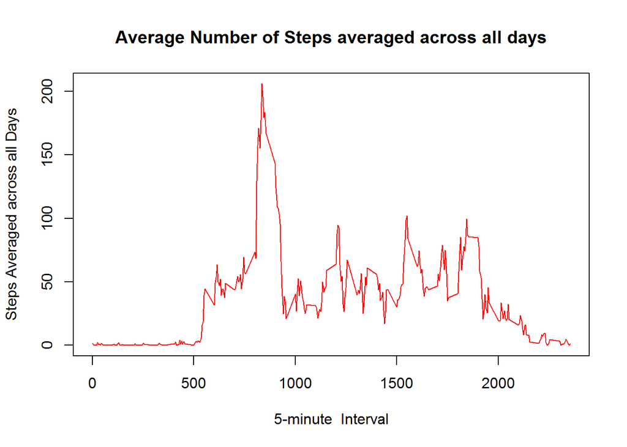

```r
stepsInterval <- aggregate(steps ~ interval, data = activity, mean, na.rm = TRUE)
plot(stepsInterval$interval,stepsInterval$steps, type="l", xlab="5-minute  Interval", ylab="Steps Averaged across all Days",main="Average Number of Steps averaged across all days", col = " red")
```

```r
maxInterval <- stepsInterval[which.max(stepsInterval$steps),1]
```

#### Imputing missing values

To calculate the total number of missing values:

```r
Total_missing <- sum(is.na(activity))
Total_missing
```

```
## [1] 2304
```

To refill the NA,a “for loop”" function is used and replaced with the 5-minute interval mean. Then the replacing NA is assigned to a new data set called activity_NoNa with the same dimension of the original activity data.

```r
stepsInterval <- aggregate(steps ~ interval, data = activity, mean)
replaceNA <- numeric()
for (i in 1:nrow(activity)) {
    act <- activity[i, ]
    if (is.na(act$steps)) {
        steps <- subset(stepsInterval, interval == act$interval)$steps
    } else {
        steps <- act$steps
    }
    replaceNA <- c(replaceNA, steps)
}
activity_NoNa <- activity
activity_NoNa$steps <- replaceNA
```

The Histogram with replacing NA is

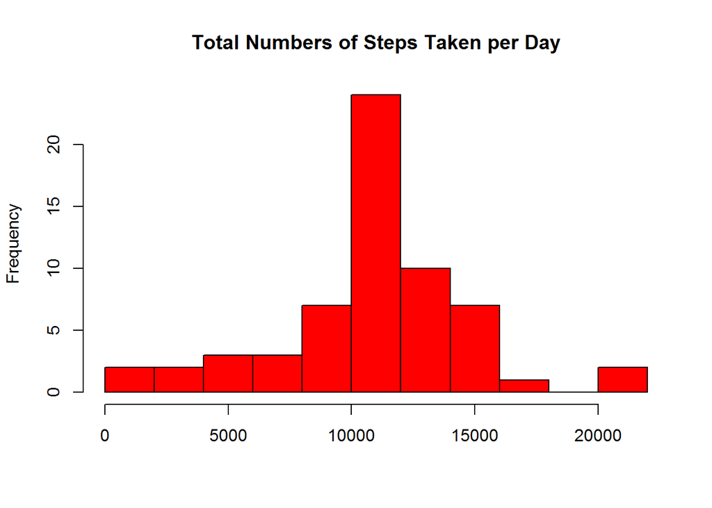

```r
NewTotalSteps <- aggregate(steps ~ date, data = activity_NoNa, sum, na.rm = TRUE)
hist(NewTotalSteps$steps,  xlab = " ", main = paste("Total Numbers of Steps Taken per Day"), col= "red",breaks = 10)
```

The New mean and median are:

```r
New_Mean <- mean(NewTotalSteps$steps)
New_Mean
```

```
## [1] 10766.19
```

```r
New_Median <- median(NewTotalSteps$steps)
New_Median
```

```
## [1] 10766.19
```

Before filling the data

.Mean : 10766.189  
.Median: 10765

After filling the data

.Mean : 10766.189  
.Median: 10766.189

Therefore, the values mean before and after filling NA is equivalent, but the median is slightly different by 1.189.

#### Are there differences in activity patterns between weekdays and weekends?

Create a factor variable in the dataset with two levels weekday and weekend.

```r
AllDay <- weekdays(activity_NoNa$date)
Day <- vector()
for (i in 1:nrow(activity)) {
    if (AllDay[i] == "Saturday") {
        Day[i] <- "Weekend"
    } else if (AllDay[i] == "Sunday") {
        Day[i] <- "Weekend"
    } else {
        Day[i] <- "Weekday"
    }
}
activity_NoNa$Day <- Day
activity_NoNa$Day <- factor(activity_NoNa$Day)

steps_Day <- aggregate(steps ~ interval + Day, data = activity_NoNa, mean)
names(steps_Day) <- c("interval", "Day", "steps")
```

The following is the panel plot comparing the average number of steps taken per 5-minute interval between across weekdays and weekends.

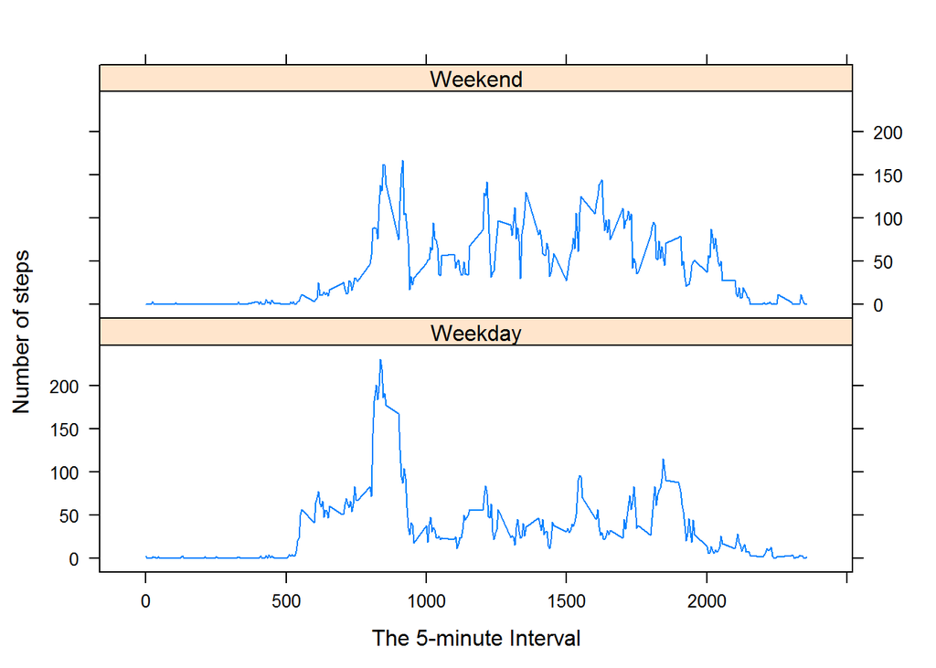

```r
library(lattice)
xyplot(steps ~ interval | Day, steps_Day, type = "l", layout = c(1, 2),
    xlab = "The 5-minute Interval", ylab = "Number of steps")
```